# A gentler introduction to R

Shaun Nielsen

2025-05-20

## Preamble

We understand that R functions as a calculator, allowing us to store data in objects for use with statistical functions and data visualisation.

Let’s take a step back from yesterday’s session and conduct a simple exercise involving basic data entry, data visualization, simple statistical summaries, and a statistical test. We will learn how to better structure data using the data.frame - a fundamental data structure in R - and how data import usually results in a data.frame.

## Data collection

You have collected the counts of insects under two experimental treatments, for example, Treatment with Fertilizer A and Control Treatment.

Treatment A: 8, 9, 10, 9, 9, 12, 12, 12, 13, 10

Treatment B: 2, 5, 2, 0, 2, 3, 4, 4, 2

Lets enter these data into R and see how we can easily analyse the data.

### Simple data entry

We use the `c()` function to create simple vectors. Keep in mind that this method is suitable for quick data entry, but not for larger datasets.

```r
treatment_fert = c(8, 9, 10, 9, 9, 12, 12, 12, 13, 10)
treatment_ctrl = c(2, 5, 2, 0, 2, 3, 4, 4, 2)
```

We can verify that the data has been entered correctly into R by either 1) printing the values to the console, or 2) examining the “Environment” panel in RStudio (located in the top-right).

```r
treatment_fert
```

```
##  [1]  8  9 10  9  9 12 12 12 13 10
```

```r
treatment_ctrl
```

```
## [1] 2 5 2 0 2 3 4 4 2
```

### Simple data visalisation

We can use R’s various plotting functions to visualize and better understand the patterns within the data.

#### Boxplot of the counts

We use the `boxplot()` function to create boxplots. In this case, we can pass the two vectors, one after the other. While this would create a basic plot, we want to add informative labels. To label each boxplot, we use the `names=` argument and provide a vector containing two text values. To label the y-axis, we use the `ylab=` argument with a single text value. Note the use of quotation marks (`"`) for these text values.

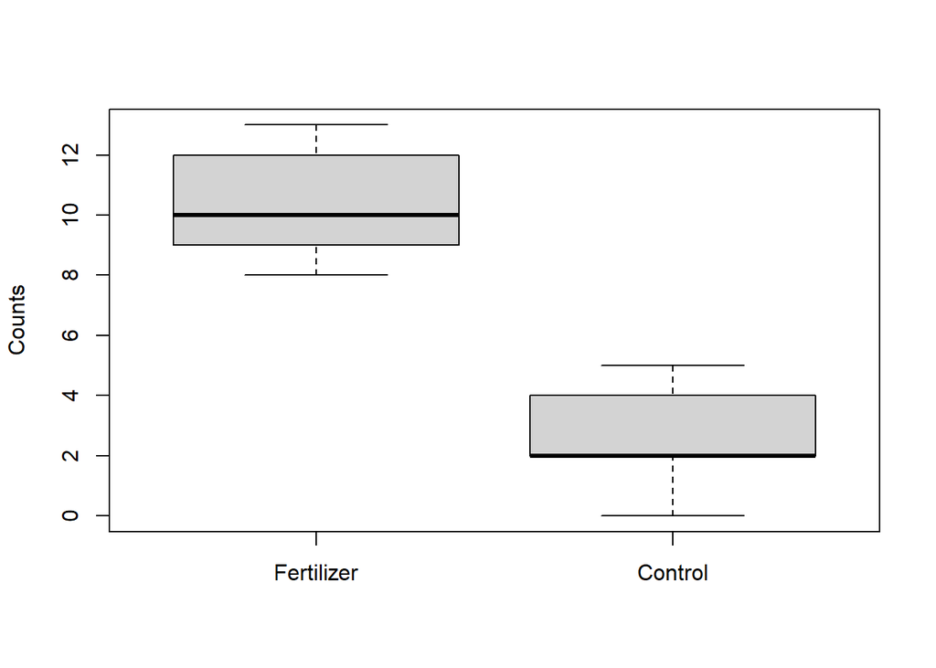

```r
boxplot(treatment_fert, treatment_ctrl,
        names = c('Fertilizer', 'Control'),
        ylab = 'Counts')
```

### Simple statistical summaries

We can obtain simple statistical summaries with such functions as `mean()`, `median()`, `sd()`, `range()`. As you might notice, this involves a fair amount of typing. We will learn more efficient methods for obtaining these summaries later.

```r
mean(treatment_fert)
mean(treatment_ctrl)
```

```
## [1] 10.4
## [1] 2.666667
```

```r
sd(treatment_fert)
sd(treatment_ctrl)
```

```
## [1] 1.712698
## [1] 1.5
```

```r
length(treatment_fert)
length(treatment_ctrl)
```

```
## [1] 10
## [1] 9
```

### Simple statistical test

```r
t.test(treatment_fert, treatment_ctrl)
```

```
##
##  Welch Two Sample t-test
##
## data:  treatment_fert and treatment_ctrl
## t = 10.491, df = 16.993, p-value = 7.664e-09
## alternative hypothesis: true difference in means is not equal to 0
## 95 percent confidence interval:
##  6.178112 9.288555
## sample estimates:
## mean of x mean of y
## 10.400000  2.666667
```

### Using data.frames to store data

We typically organize our data in a data structure called a data.frame. We will enter the data manually here for demonstration purposes. In practice, you would typically use other methods to create this data table, such as creating it in Excel and importing it into R.

Note that breaking code into different lines can improve its readability.

```r
count_data <-
  data.frame(
    Treatment = c('Fert','Fert','Fert','Fert','Fert',
                  'Fert','Fert','Fert','Fert','Fert',
                  'Ctrl','Ctrl','Ctrl','Ctrl','Ctrl',
                  'Ctrl','Ctrl','Ctrl','Ctrl'),
    Count = c(8, 9, 10, 9, 9, 12, 12, 12, 13, 10,
              2, 5, 2, 0, 2, 3, 4, 4, 2)
  )
```

Now we have a data.frame holding the data together

```r
count_data
```

```
##    Treatment Count
## 1       Fert     8
## 2       Fert     9
## 3       Fert    10
## 4       Fert     9
## 5       Fert     9
## 6       Fert    12
## 7       Fert    12
## 8       Fert    12
## 9       Fert    13
## 10      Fert    10
## 11      Ctrl     2
## 12      Ctrl     5
## 13      Ctrl     2
## 14      Ctrl     0
## 15      Ctrl     2
## 16      Ctrl     3
## 17      Ctrl     4
## 18      Ctrl     4
## 19      Ctrl     2
```

This data.frame contains 19 observations and 2 variables (columns). The columns are `Treatment` and `Count`, are of character and numeric types, respectively.

```r
str(count_data)
```

```
## 'data.frame':    19 obs. of  2 variables:
##  $ Treatment: chr  "Fert" "Fert" "Fert" "Fert" ...
##  $ Count    : num  8 9 10 9 9 12 12 12 13 10 ...
```

We can access the data within specific columns using the `$` symbol

```r
count_data$Treatment
```

```
##  [1] "Fert" "Fert" "Fert" "Fert" "Fert" "Fert" "Fert" "Fert" "Fert" "Fert" "Ctrl" "Ctrl" "Ctrl" "Ctrl" "Ctrl" "Ctrl" "Ctrl" "Ctrl" "Ctrl"
```

```r
count_data$Count
```

```
##  [1]  8  9 10  9  9 12 12 12 13 10  2  5  2  0  2  3  4  4  2
```

### A boxplot

We can create a boxplot again, this time using a special R notation called a **formula**. A formula, such as `y ~ grp`, is used where `y` represents a numeric vector of data values, and `grp` is the grouping variable used to split the data. The **first** argument is the formula.

When passing data in this formulaic way, the boxplot labels are automatically populated, meaning we don’t need to use the names= argument separately. Notice that the x- and y-axis labels are derived from the variables used in the formula.

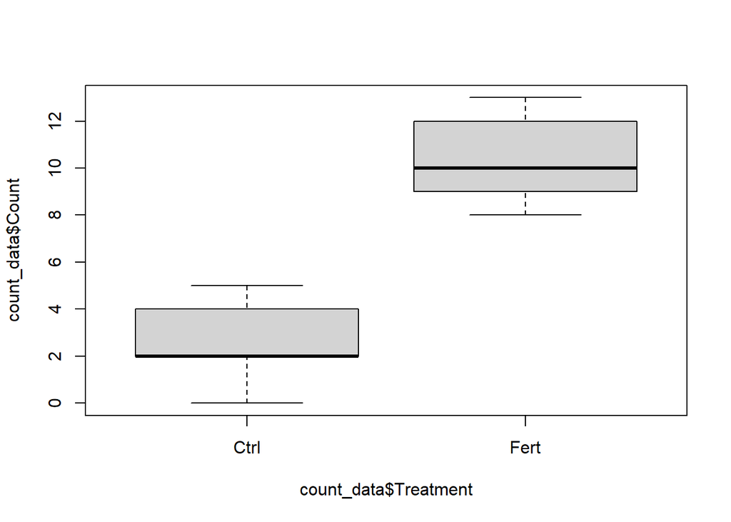

```r
boxplot(count_data$Count ~ count_data$Treatment)
```

Many R functions are designed to work with data.frames and include a data= argument to specify which data.frame to use. In this approach, we specify the data.frame using the `data=` argument and then refer to the columns directly by their names within the formula. Notice that the default x- and y-axis labels are often more informative when using the formula and data= argument. However, you can still customize them using the `xlab=` and `ylab=` arguments if desired. While we are here, lets change the colour using `col=`.

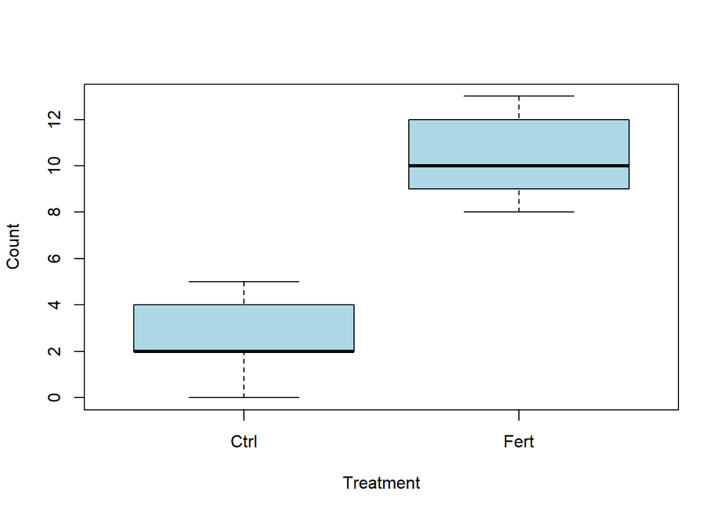

```r
boxplot(Count ~ Treatment, data = count_data,
        col = 'lightblue')
```

### Statistical summaries

There are also functions, such as `aggregate()`, that are helpful for summarizing data within a data.frame. The `aggregate()` function takes a formula as its first argument, followed by the `data=` argument to specify the data.frame, and the `FUN=` argument to indicate the statistical function to apply. Note that the statistical function is provided without parentheses within the `FUN=` argument (e.g., `FUN=mean`, not `FUN=mean()`).

```r
aggregate(Count ~ Treatment, data = count_data, FUN = mean)
```

```
##   Treatment     Count
## 1      Ctrl  2.666667
## 2      Fert 10.400000
```

```r
aggregate(Count ~ Treatment, data = count_data, FUN = sd)
```

```
##   Treatment    Count
## 1      Ctrl 1.500000
## 2      Fert 1.712698
```

```r
aggregate(Count ~ Treatment, data = count_data, FUN = length)
```

```
##   Treatment Count
## 1      Ctrl     9
## 2      Fert    10
```

### Statistical test

The `t.test()` function is also designed to work with data.frames. Following the examples above, here’s how you would apply it.

```r
t.test(Count ~ Treatment, data = count_data)
```

```
##
##  Welch Two Sample t-test
##
## data:  Count by Treatment
## t = -10.491, df = 16.993, p-value = 7.664e-09
## alternative hypothesis: true difference in means between group Ctrl and group Fert is not equal to 0
## 95 percent confidence interval:
##  -9.288555 -6.178112
## sample estimates:
## mean in group Ctrl mean in group Fert
##           2.666667          10.400000
```

### Importing data into a data.frame

We typically import our data into R and this results in a data.frame. Here, I’ve imported data from the file `penguins.csv`. Next, I used the `str()` function to obtain a quick summary of the data.frame’s structure. From this point, you would be ready to conduct further analyses as needed.

```r
penguins <- read.csv("../data/penguins.csv")
str(penguins)
```

```
## 'data.frame':    344 obs. of  8 variables:
##  $ species          : chr  "Adelie" "Adelie" "Adelie" "Adelie" ...
##  $ island           : chr  "Torgersen" "Torgersen" "Torgersen" "Torgersen" ...
##  $ bill_length_mm   : num  39.1 39.5 40.3 NA 36.7 39.3 38.9 39.2 34.1 42 ...
##  $ bill_depth_mm    : num  18.7 17.4 18 NA 19.3 20.6 17.8 19.6 18.1 20.2 ...
##  $ flipper_length_mm: int  181 186 195 NA 193 190 181 195 193 190 ...
##  $ body_mass_g      : int  3750 3800 3250 NA 3450 3650 3625 4675 3475 4250 ...
##  $ sex              : chr  "male" "female" "female" NA ...
##  $ year             : int  2007 2007 2007 2007 2007 2007 2007 2007 2007 2007 ...
```

```r
head(penguins)
```

```
##   species    island bill_length_mm bill_depth_mm flipper_length_mm body_mass_g    sex year
## 1  Adelie Torgersen           39.1          18.7               181        3750   male 2007
## 2  Adelie Torgersen           39.5          17.4               186        3800 female 2007
## 3  Adelie Torgersen           40.3          18.0               195        3250 female 2007
## 4  Adelie Torgersen             NA            NA                NA          NA   <NA> 2007
## 5  Adelie Torgersen           36.7          19.3               193        3450 female 2007
## 6  Adelie Torgersen           39.3          20.6               190        3650   male 2007
```

## Conclusion

This document provides a gentle introduction to using R. We began by manually entering data into vectors and storing them as objects. We then visualized the data, calculated simple statistical summaries, and performed a statistical test. Next, we organized the data into a data.frame — the most widely used data structure in R — and demonstrated how to perform the same tasks using this structure. Finally, we imported data from an external file, which also resulted in a data.frame ready for analysis.

The functions used in this introduction are part of the **base R** packages — those that are included with the standard R installation. In future explorations, we can examine how additional packages can help us write more concise code to achieve the same results and create more visually appealing plots. Many of these helpful packages are part of the [**tidyverse**](https://www.tidyverse.org/), a collection of R packages designed to make data science workflows more efficient and user-friendly.

Thank you to the anonymous student whose request for help inspired the creation of this document.